# Statistical Principles and Experimental Design — Seminar 5 Significance tests

matthias.kuhn@tu-dresden.de

November 21, 2023 <sub>[87b1cea]</sub>

**(solutions interspersed)**

## Sleep data

R ships with a data set called `sleep` from a more than 100 years old two-armed clinical trial that compares the effect of two soporific drugs. The effect of the drugs was measured individually for each participant by how many hours the sleep was *prolonged* compared to the participant’s normal sleep duration (column `extra`).

1. Load the dataset into your workspace using `data(sleep)` and take a look at the documentation: `?sleep`.
2. Produce a violin plot that shows the extra sleep duration of both groups side-by-side. As there are only few patients tested in each treatment group add the individual observations as points onto the violin plot. Use `geom_violin`. You can add points with `geom_point` but using `geom_jitter` with a small argument to its option `width=` (and `height=0`) will make the points easier to discern.
3. Assume that the extra time within both groups is sufficiently close to a normal distribution. Do a suitable significance test that compares the expected value of extra time between both groups.
4. Interpret the results at a significance level of α = 5%.
5. You learn that the experiment was actually done as a **cross-over study**, i.e., each participant was measured for both drugs and the *order* that participants receive the drugs was randomized. In the `sleep` data set, the participant’s identity is recorded in column `ID`. Does this additional information influence your answer to the previous question?

**Solution**

We load the dataset into our current R-session and explore the data with plots:

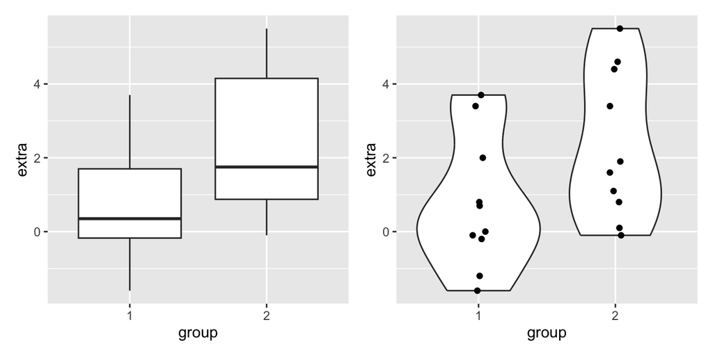

```r
## load data
data("sleep") # load data in current workspace

library("ggplot2")
library("patchwork") # to arrange plots side-by-side (using |)
# boxplot
ggplot(data = sleep, mapping = aes(x = group, y = extra)) +
  geom_boxplot() |
# violin plot reveals more information about the distribution
ggplot(data = sleep, mapping = aes(x = group, y = extra)) +
  geom_violin() + geom_jitter(width = .05, height = 0)
```

We perform Welch’s t-test that assumes normally distributed data per group and allows for possibly different variances per group:

```r
t.test(extra ~ group, data = sleep)
```

```
##
##  Welch Two Sample t-test
##
## data:  extra by group
## t = -1.86, df = 17.8, p-value = 0.079
## alternative hypothesis: true difference in means between group 1 and group 2 is not equal to 0
## 95 percent confidence interval:
##  -3.36548  0.20548
## sample estimates:
## mean in group 1 mean in group 2
##            0.75            2.33
```

**Interpretation of the two-sample Welch test:**

We observe for drug 1 a mean increase in sleep time of 0.75h and for drug 2 an average increase of 2.33h. The average difference in sleep prolongation is 2.33 - .75 = 1.58h but this difference between the drug effects on sleep prolongation is **not** statistically significant at the significance level of α = 5%.

5. If we know that each participant is measured in both groups we can use a *paired* Welch-test. When the data within both groups is sorted in the same way (e.g. ascending IDs) we can simply add `paired=TRUE` to the `t.test` call:

```r
t.test(extra ~ group, data = sleep, paired = TRUE)
```

```
##
##  Paired t-test
##
## data:  extra by group
## t = -4.06, df = 9, p-value = 0.0028
## alternative hypothesis: true mean difference is not equal to 0
## 95 percent confidence interval:
##  -2.45989 -0.70011
## sample estimates:
## mean difference
##           -1.58
```

Alternatively, the R-function `Pair` makes the pairing explicit and hence more safe. To this end, we arrange the paired observations side by side (aka. in *wide format*). Here, we use `pivot_wider` from the `tidyr` package (which is also part of the `tidyverse`).

```r
library("tidyr")

sleep_w <- sleep |>
  tidyr::pivot_wider(names_from = group, names_prefix = "Gr", values_from = extra)

t.test(Pair(Gr1, Gr2) ~ 1, data = sleep_w)
```

```
##
##  Paired t-test
##
## data:  Pair(Gr1, Gr2)
## t = -4.06, df = 9, p-value = 0.0028
## alternative hypothesis: true mean difference is not equal to 0
## 95 percent confidence interval:
##  -2.45989 -0.70011
## sample estimates:
## mean difference
##           -1.58
```

The estimate for the mean difference in drug effect is the same as before: drug 2 has on average an effect of 1.58h longer sleep than drug 1 (the sign change only reflects that here by convention it is µ<sub>1</sub> - µ<sub>2</sub> while above we reported µ<sub>2</sub> - µ<sub>1</sub>). But the P-value is this time much lower (P = 0.00283) and hence the difference in effect is statistically significant at the 5 % level when testing as a paired sample.

The reason for the change in statistical significance is that — by looking at the *individual differences* of drug effect — the paired test takes away one source of variability, namely the *biological variability* in individual susceptibility to drugs.

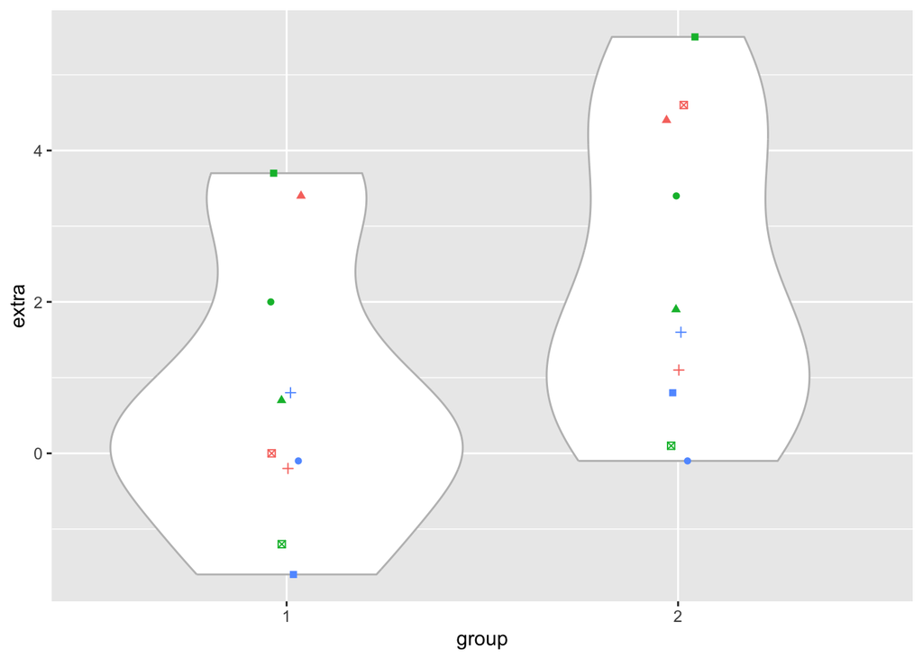

```r
# using ggplot2
ggplot(data = sleep, mapping = aes(x = group, y = extra)) +
  geom_violin(col="grey") +
  geom_jitter(mapping = aes(shape = factor(as.numeric(ID) %% 5),
                            col = factor(as.numeric(ID) %% 3)),
              width = .05, height = 0) +
  theme(legend.position = "none") ## suppress legends
```

The variability in individual susceptibility is visualized in the scatter plot: measurements on the same subject are indicated by plot symbol (option `shape=`) and colour (`col=`). We see that participants with low extra-hours on drug 1 tend to have also low extra-hours on drug 2.

We can **quantify this association** for instance with [Pearson’s correlation](https://en.wikipedia.org/wiki/Pearson_correlation_coefficient) between the two measurements. We again use the data in wide format:

```r
cor(sleep_w$Gr1, sleep_w$Gr2)
```

```
## [1] 0.79517
```

A value close to +.80 means a strong positive linear association between the two drug measurements on same subjects.

## Lung cancer

One of the most frequent and aggressive cancers is [lung cancer](https://www.cancer.gov/types/lung). The 5-year survival rate for patients that are initially diagnosed in a late lung cancer stage is less than 10%. However, when this cancer is detected in an early stage and with appropriate treatment the 5-year survival rate reaches π<sub>0</sub> = 60%.

In a clinical trial, a new treatment is tested on N=811 patients with early stage lung cancer. Of these, 521 are still alive after five years.

Is the 5-year survival rate under the new treatment different from the established π<sub>0</sub> = 60%? We can formulate the following two-sided hypotheses:
$$H_0: π = 0.6 \qquad \text{ versus } \qquad H_1: π ≠ 0.6$$

Your task is to perform the following two statistical significance tests. When we apply a 5%-significance level, do you draw different conclusions?

### Binomial test

In the lecture, you have seen the exact binomial test which fits the described above situation.

1. What is the probability mass of the observed outcome under H<sub>0</sub>?
2. Which of the binomial outcomes (0, 1, …, 811) contribute to the resulting P-value of this binomial test?
3. What is this P-value?

**Solution**

First, we define variables that capture the data.

```r
p0 <- .6
N <- 811
x <- 521
m0 <- N * p0 #expected success count under H0
```

1. We observe 521 out of 811 patients that are alive after 5 years. We use the density-function `dbinom` to get the probability of our outcome under H<sub>0</sub>:

```r
(pmObs <- stats::dbinom(x, size = N, prob = p0))
```

```
## [1] 0.0013424
```

The full probability mass function under H<sub>0</sub> looks similar to a Gaussian bell-shaped density but it is only positive for integer values and it is not symmetrical because π<sub>0</sub> = 0.6 ≠ 0.5. The density peaks near the expected outcome 811·0.6 = 486.6.

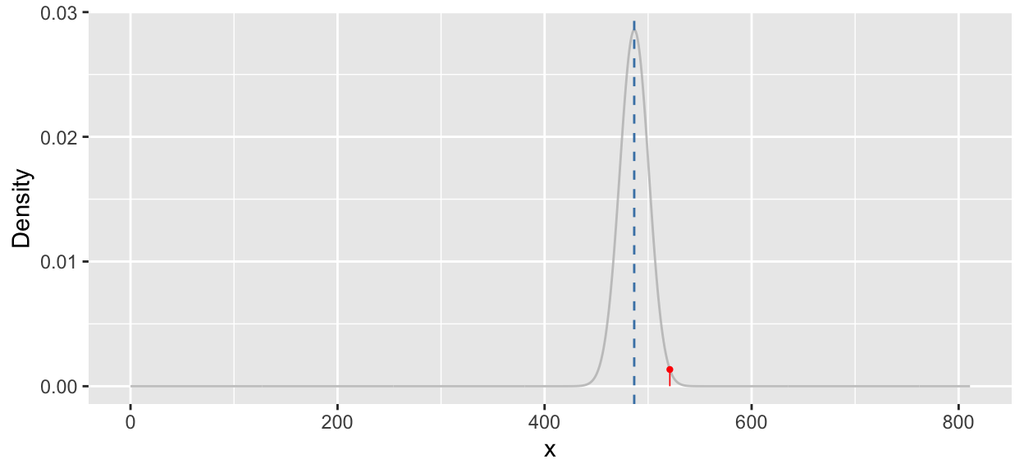

```r
ggplot() + xlim(0, N) +
  # we need to specify n = N+1 so that geom_function will assess dbinom only at integer values
  geom_function(fun = dbinom, args = list(size = N, prob = p0), n = N+1,
                alpha = .84, col = "gray") +
  geom_point(mapping = aes(x=x, y=pmObs), col = "red", size = .8) +
  geom_segment(mapping = aes(x=x, xend=x, y=0, yend = pmObs), col = "red", linewidth = .3) +
  geom_vline(xintercept = m0, linetype = "dashed", col = "steelblue") +
  labs(y = "Density")
```

2. The exact binomial test evaluates each possible outcome (0, 1, …, 811) under the binomial distribution with success probability π<sub>0</sub> = 0.6. The probability mass of all those outcomes contribute to the P-value of the binomial test that is smaller or equal to the probability mass of the observed outcome 521.

The observed outcome lies beyond (=to the right of) the expected outcome 486.6 where the peak is. Hence, all observations ≥ 521 (i.e., **{521, 522, …, 811}**) have a probability mass smaller or equal to 0.00134 of x=521 and contribute to the P-value of the binomial test.

On the left side we check each outcome, starting at 0 up to the peak at 486.6.

```r
smallOutc <- seq(from = 0, to = floor(m0))
# +1e-7 to compensate rounding issues
smallOutc2 <- smallOutc[which(dbinom(smallOutc, size = N, prob = p0, log=TRUE) <= dbinom(x, size = N, prob = p0, log=TRUE) + 1e-7)]
```

So, on the left side the outcomes **{0, …, 451}** contribute to the P-value.

3. The P-value is **0.01341**. It is the sum of all probability masses that are at most as likely as the observed outcome. We use the cumulative distribution function (CDF) for the binomial distribution with success probability π<sub>0</sub> = 60% to get these probabilities summed up. We have the two tails: on the left (lower) side and on the right (upper) side.

For the right side we subtract a small amount from the observed outcome so that the observed outcome itself is included (see explanation for argument `lower.tail = FALSE`).

```r
# left side + right side
pbinom(max(smallOutc2), size = N, prob = p0) + pbinom(x-.1, size = N, prob = p0, lower.tail = FALSE)
```

```
## [1] 0.01341
```

In R, we also have the pre-implemented function `binom.test()` that yields directly the same result.

```r
binom.test(x = x, n = N, p = p0)
```

```
##
##  Exact binomial test
##
## data:  x and N
## number of successes = 521, number of trials = 811, p-value = 0.013
## alternative hypothesis: true probability of success is not equal to 0.6
## 95 percent confidence interval:
##  0.60834 0.67545
## sample estimates:
## probability of success
##                0.64242
```

### Likelihood ratio test

We have applied the likelihood method for point estimation. And we can also use it to come up with statistical significance tests called «likelihood ratio test» (LRT). LRT form an important class of significance tests. Generally, the LRT compares if a restricted model parameter space ω is appropriate in comparison with a larger parameter space Ω. It is ω ⊆ Ω. The null-hypothesis of the test is that the restricted model parameter space suffices, i.e., $H_0: θ ∈ ω$. For the test statistic, we use the difference of the maximum value of the log-likelihood function under Ω as compared to under ω. Concretely, given the data it is
$$λ_\text{LR} = -2 · \big(\sup_{\theta \in ω} \ln L(\theta) - \sup_{\theta
\in Ω} \ln L(\theta)\big)$$
By construction, we have $λ_\text{LR} ≥ 0$. The larger $λ_\text{LR}$ the more evidence there is against H<sub>0</sub>. When $H_0$ holds (and some regularity conditions are fulfilled), this test statistic is asymptotically χ<sup>2</sup>-distributed with degrees of freedom equal to the difference in dimension of the parameter spaces Ω and ω.

In our situation, the parameter space is the success probability π and is only 1-dimensional. The null-hypothesis H<sub>0</sub> restricts π to a single value π<sub>0</sub> = 0.6. So, ω = {π<sub>0</sub>}. For the larger model parameter space we use the unrestricted Ω = {π | 0 ≤ π ≤ 1}.

1. What is the value of the test statistic $λ_\text{LR}$?
2. What is the corresponding asymptotic P-value?

**Solution**

1. First, we implement the likelihood ratio statistic as an R-expression and plug in the values from the data:

```r
lrtStat <- -2 * (x * log(p0) + (N-x) * log(1-p0) - (x * log(x/N) + (N-x) * log((N-x)/N)))
lrtStat
```

```
## [1] 6.1606
```

2. We use the χ<sup>2</sup>-distribution with 1 degree of freedom to assess the test statistic. As only large values of $λ_\text{LR}$ speak against H<sub>0</sub> we calculate the P-value as area under the density curve to the right of the value of $λ_\text{LR}$. We use the cumulative distribution function which is already defined in R as `pchisq`. The option `lower.tail=FALSE` makes that we get the area on the right tail.

```r
pchisq(q=lrtStat, df = 1, lower.tail = FALSE)
```

```
## [1] 0.013063
```

The exact binomial test and the likelihood ratio test lead to different P-values, as they are different tests. The higher the sample size the more we would expect that the two P-values coincide. But the conclusions are the same: at a 5% significance level we speak of a statistical significant difference in 5-year survival rate. Whether this increase in survival rate is also medically relevant is a different question, though. The gain in 5-year survival rate would need to be offset against other complications and costs related to the new treatment.

## Voting habits

A sample of US citizens was surveyed about which political party (Democrats, Republican or Independent) they prefer. Split up by male and female, the aggregated answers of the 2757 participants are as follows:

Survey outcome on political preference in the US between males and females

|  | Democrat | Independent | Republican |
| --- | --- | --- | --- |
| Female | 762 | 327 | 468 |
| Male | 484 | 239 | 477 |

1. Apply a suitable statistical significance test to assess if — based on the given sample — gender and political party preference is independent in the surveyed population? Interpret the test results at a significance level of α = 5%.
2. Specifically, consider the association of preferring the Republican party and gender. Estimate this association with the odds ratio (OR) where you use females as reference group.

**Solution**

First, we define the data as an table-object in R.

```r
survey <- as.table(matrix(c(762, 327, 468,
                            484, 239, 477), nrow=2, byrow = TRUE))
dimnames(survey) <- list(gender = c("Female", "Male"),
                    party = c("Democrat","Independent", "Republican"))
```

1. To test independence in a 2x3-contingency table we can use Pearson’s χ<sup>2</sup>-test of independence. Under the null hypothesis of independence of gender and political party preference all expected cell counts are way beyond 5. As a general rule, at least 80 % of cells should have an expected cell count of at least five in order to make the Pearson’s χ<sup>2</sup>-test and its (asymptotic) P-value trustworthy.

```r
(indep_test <- chisq.test(survey))
```

```
##
##  Pearson's Chi-squared test
##
## data:  survey
## X-squared = 30.1, df = 2, p-value = 3e-07
```

The test is significant at the 5% significance level so we reject the null hypothesis of independence of gender and political preference. But to interpret the gender effect we have to look more closely which observed cell counts deviate most from the expected counts under H<sub>0</sub>.

To this end, we look into the residuals that build up the χ<sup>2</sup>-test statistic. The object returned by `chisq.test` is a list that contains a slot named «residuals». The sum of these residuals *squared* forms the χ<sup>2</sup>-test statistic. Positive residuals indicate that this cell has a higher count than expected under independence assumption. So, males prefer the Republican party while female prefer the Democrats.

```r
indep_test$residuals
```

```
##         party
## gender   Democrat Independent Republican
##   Female  2.19886     0.41137   -2.84324
##   Male   -2.50467    -0.46858    3.23867
```

But how big must a residual be to be a significant deviation? There are standardized residuals in the returned object under the name «stdres». Here, roughly speaking, absolute values beyond 2 indicate significant deviations although you have to take into account that we are testing multiple cells in the contingency table at once (e.g., the multiple testing issue).

```r
indep_test$stdres
```

```
##         party
## gender   Democrat Independent Republican
##   Female  4.50205     0.69945   -5.31595
##   Male   -4.50205    -0.69945    5.31595
```

We see that the deviations for Republican and reversely for Democrats are in this respect «statistically significant» as they even go beyond 4.5 in absolute value.

2. To quantify the association between voting for Republican and gender we calculate the odds ratio where females serve as reference group. Odds (or *chance*) are calculated as «number of suitable over number of non-suitable» (as opposed to the Laplace probability which is «number of suitable over number of possible»).

In our sample (=survey), we estimate the odds as follows:

- odds to vote Republican for males is estimated as o<sub>♂</sub> = 0.65975
- odds to vote Republican for females is estimated as o<sub>♀</sub> = 0.42975
- odds ratio (OR) to vote Republican between males and females: OR<sub>♂/♀</sub> = 1.53519.

So, males have a ≈ 1.5 × times increased chance to vote Republican compared to females. The OR is beyond 1 which coincides with the positive residuals for the cell Male/Republican.

## Sleep data revisited

Consider again the `sleep`-data from the beginning, but this time you are asked to apply a **randomization test** which belongs to *conditional inference* (see lecture). This means: you condition on these observed values and you infer directly from there through permutations and without using any distributional assumptions.

### As unpaired samples

We first treat the data as *unpaired*, i.e., we *ignore* that the same participant is measured twice, once for drug 1 and once for drug 2.

1. As test statistic choose, the **mean difference in the two groups** (exactly like in the `roomwidth`-example in the lecture). The conditional distribution of the test statistic under the null hypothesis H<sub>0</sub>: «no difference in expected value» — given the observed data — is built by **shuffling the outcome** (`extra` sleep time) which in fact breaks any possible link between the group variable and the outcome. Implement this shuffling (in R). Set the seed to some fixed number so that the pseudo-random generator gives reproducible results and run the shuffling e.g. `B=9999` times and each time compute the test statistic on the shuffled data. The two-sided **P-value** of the randomization test is the proportion of test statistics that are in *absolute value* at least as far away from zero as the initially observed test statistic. Compare your proportion with the P-value from the parametric independent sample test you did above.
2. Repeat your procedure from the previous step, but this time choose a simpler test statistic: the sum of extra-time in the «drug 1»-group. Compare the two P-values from the previous and this randomization test. Discuss your finding.

**Solution**

1. The following code shuffles the outcome `extra` between the two existing groups. As there are $20! = 2.4329\times 10^{18}$ different permutations of the `extra` column we **approximate** the conditional p-value by sampling `B=9999` permutations.

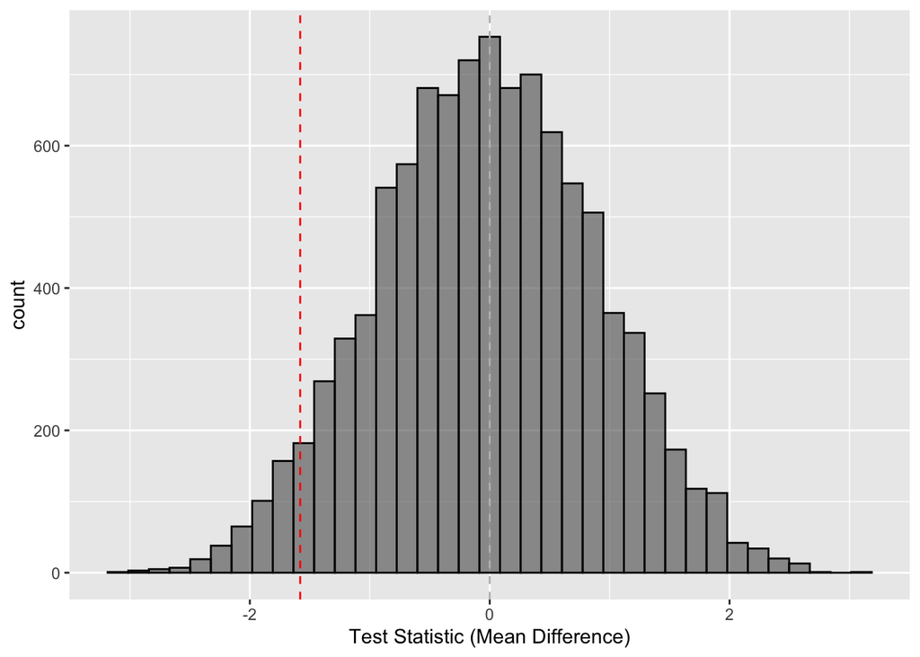

```r
B <- 9999 # number of replications
idx_g1 <- sleep$group == 1 # index of observations in group 1
# observed mean difference drug1 - drug2 as test statistic
tstat_meandiff_obs <- mean(sleep$extra[idx_g1]) - mean(sleep$extra[!idx_g1])

# fix seed of random number generator for reproducible results
set.seed(123)

randTeststat1 <- purrr::map_dbl(
  .x = seq_len(B),
  .f = \(i) {
    ys <- sample(sleep$extra) # shuffle response variable
    mean(ys[idx_g1]) - mean(ys[!idx_g1])
  }
)

ggplot(data = tibble(meandiff = randTeststat1),
       mapping = aes(x = meandiff)) +
  geom_histogram(bins = 37, alpha = .6, col = "black") +
  geom_vline(xintercept = c(0, tstat_meandiff_obs), col = c("grey", "red"), linetype = "dashed") +
  labs(x = "Test Statistic (Mean Difference)")
```

The vector `randTeststat1` contains 9999 realizations of the randomization distribution of the test statistic (here, the difference of means between the two drug groups). We know that the distribution of this test statistic under H<sub>0</sub> is symmetric and centred at 0, i.e., E[T] $\stackrel{H_0}{=} 0$. We derive the approximate P-value of this randomization test as the proportion of values that are at least as far away from 0 as the observed value of the test statistic. Note, the `+1` occurs in both numerator and denominator because we consider the observed data as one possible randomization and it increments both the numerator and denominator.

```r
# 2-sided P-value of randomization test: using symmetry of distribution of T around 0 under H0
(sum(abs(randTeststat1) >= abs(tstat_meandiff_obs))+1) / (B+1)
```

```
## [1] 0.0864
```

The P-value closely resembles the result of the conventional 2-sample Welch-test and we would draw the same conclusions from this test result.

2. Now, we redo the randomization but use the simpler test statistic «sum of outcomes in group 1». We use again the same the number of randomizations `B=` 9999.

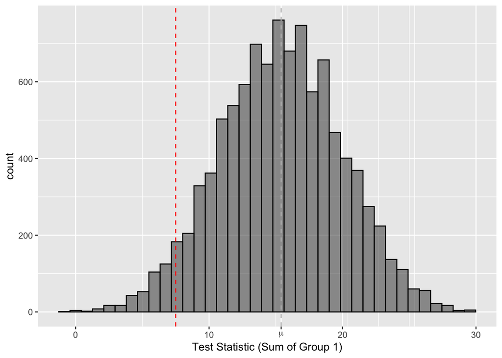

```r
# observed sum in group of drug1 as test statistic
tstat_sum_obs <- sum(sleep$extra[idx_g1])

randTeststat2 <- purrr::map_dbl(
  .x = seq_len(B),
  .f = \(i) {
    sum(sample(sleep$extra, size = sum(idx_g1)))
  }
)

tstat_sum_exp <- sum(sleep$extra)/2

ggplot(data = tibble(sumGr1 = randTeststat2),
       mapping = aes(x = sumGr1)) +
  geom_histogram(bins = 37, alpha = .6, col = "black") +
  geom_vline(xintercept = c(tstat_sum_exp, tstat_sum_obs),
             col = c("grey", "red"), linetype = "dashed") +
  scale_x_continuous(name = "Test Statistic (Sum of Group 1)",
                     breaks = c(0, 10, 20, 30, tstat_sum_exp), labels = c(0, 10, 20, 30, expression(mu)))
```

The vector `randTeststat2` contains 9999 realizations of the sampling distribution of the *sum* of responses from group 1, the chosen test statistic $T$. Under H<sub>0</sub> (same expected value in both groups), the randomization distribution of $T$ is symmetric around its expected value μ, which is half of the sum of all sample values, i.e., μ = E[T] $\stackrel{H_0}{=} 15.4$. We can derive the 2-sided P-value of the conditional randomization test as the proportion of values that are at least as far away from μ as the observed value of the test statistic. Note, the `+1` occurs in both numerator and denominator because we consider the observed data as one possible randomization.

```r
# P-value of conditional test
(sum(abs(randTeststat2 - tstat_sum_exp) >= abs(tstat_sum_obs - tstat_sum_exp))+1) / (B+1)
```

```
## [1] 0.0853
```

The P-value is very similar to the P-value of the previous randomization test where we used the difference in means between group drug 1 and group drug 2. The tiny differences are due to the different states of the pseudo-random generator. Actually, the test statistics «difference in mean» and «sum of one group» are equivalent:

Let $n_1$ resp. $n_2$ denote the sample size and $S_1$ resp. $S_2$ denote the sum of the responses in group 1 resp. group 2. $S = S_1 + S_2$ denotes the total sum. Then it holds that
$$\begin{align}
\bar X_1 - \bar X_2 &= \frac{S_1}{n_1} - \frac{S_2}{n_2} \\
&= \frac{S_1}{n_1} + \frac{S_1}{n_2} - \frac{S}{n_2} \\
&= S_1 · (\frac{1}{n_1} + \frac{1}{n_2}) - \frac{S}{n_2}
\end{align}$$

In each randomization $n_1$, $n_2$ and $S$ are constant, only $S_1$ varies. So, $S_1$ carries the same information as the difference in means $\bar X_1 - \bar X_2$.

### As paired samples

Now, consider the two samples as **paired** because we know that each participant of the study was measured twice, once with drug 1 and once with drug 2.

Then we can calculate differences in extra time between drug 1 and drug 2 for each of the 10 participants. Fisher argues in his now classic textbook «The Design of Experiments» from 1935 that in a paired experiment the **sum of intra-person differences** is a suitable test statistic. Under H<sub>0</sub> (i.e., with identical expected value of the response for both groups) the observed differences are equally likely to have been positive or negative. The sum of intra-person differences is expected to be zero. Fisher proposes to generate the sampling distribution of the test statisticsum of differences when the signs (+ or -) of the observed differences are randomly chosen. Therefore, Fisher proposes to appraise the *observed* sum of differences with respect to the sampling distribution of the sum of differences when the signs (+ or -) of the observed differences are randomly chosen.

Implement this conditional randomization test and compare the resulting P-value with the P-value of the paired t-test.

**Solution**

When considering the pairing by subject we can directly focus on the *individual differences* per participant. To this end, we first build the vector of differences in extra sleep time (column `delta`) between drugs (i.e., extra time under drug 2 - extra time under drug 1). This is most conveniently done from the `sleep` data in wide format.

```r
sleep_diff <- sleep_w |>
  dplyr::mutate(delta = Gr2 - Gr1) |>
  dplyr::pull(delta)

sort(sleep_diff)
```

```
##  [1] 0.0 0.8 1.0 1.2 1.3 1.3 1.4 1.8 2.4 4.6
```

We actually see that are *no* negative deltas, i.e. there is *no* participant where drug 1 shows actually a better effect (i.e., more `extra`-hours of sleep) than drug 2.

In the randomization test we condition on the observed differences. We will use the **sum of intra-person differences** here as test statistic.

Now, under H<sub>0</sub> (i.e., no difference in expected value of extra-sleep between drugs), the observed differences were equally likely to have been positive or negative. For the randomization, we hence look at the distribution of differences where we **randomly assign the sign (±)** of each difference. and each time calculate the test statistic. As we have only 10 paired observations we can in fact sift through **all** possible $2^{10} = 1024$ combinations to get an **exact randomization p-value**.

To this end we first build a dataframe that contains all ordered combinations with replacement for the ten signs. `expand.grid()` does go over all possible combinations in a dataframe.

```r
sgnDF <- rep(list(c(-1,1)), times=10) |>
  expand.grid()
```

The next step is tricky: we want to calculate the test statistic for each randomization row. Per row, we need to multiply element-wise the signs with the observed difference in extra sleep time and sum up the result. Actually, multiplying two vectors element-wise and summing up the result is done in R by the function `crossprod()`.

The solution with `apply` from base-R appears to be the easiest. `apply` runs a function per row of a matrix or dataframe when given `MARGIN = 1`.

```r
testStat_paired_all <- apply(sgnDF, MARGIN = 1, FUN = \(sgns) crossprod(sgns, sleep_diff))
# or function could be as well: FUN = \(sgns) sum(sgns * sleep_diff)
```

The alternative with `dplyr` needs the `rowwise`-directive and you need to select all columns via `c_across(everything())`. The result is directly a dataframe.

```r
sgnDF |>
  dplyr::rowwise() |>
  dplyr::mutate(testStat = crossprod(c_across(everything()), sleep_diff)) |>
  dplyr::select(testStat)
```

Now, we can plot the distribution of the test statistic:

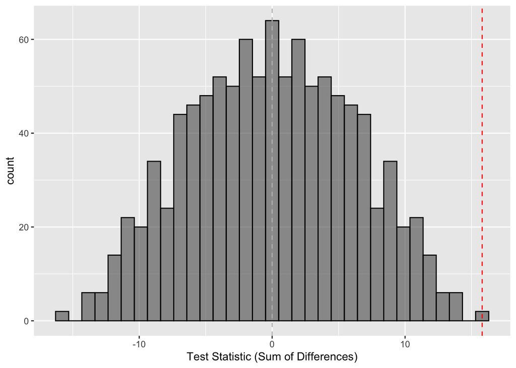

```r
# observed test statistic
testStat_paired_obs <- sum(sleep_diff)

ggplot(data = tibble(testStat = testStat_paired_all),
       mapping = aes(x = testStat)) +
  geom_histogram(bins = 33, alpha = .6, col = "black") +
  geom_vline(xintercept = c(0, testStat_paired_obs),
             col = c("grey", "red"), linetype = "dashed") +
  labs(x = "Test Statistic (Sum of Differences)")
```

The vector `testStat_paired_all` consists of all 1024 possible realizations of our chosen test statistic (here, the sum of the differences in extra sleep time per participant) when we condition on the observed data and randomly assign the sign (±). This distribution is perfectly symmetric and it has mean, median and mode equal to 0. In our data sample, the test statistic has a value of 15.8. We derive the P-value of this paired sample randomization test as the proportion of the randomization distribution that is at least as far away from 0 as the observed value of the test statistic. As we have used the complete randomization distribution (and not an approximated through sampling) we have an **exact conditional p-value**.

```r
# 2-sided P-value of conditional test: using symmetry of distribution of T around 0 under H0
# we do not add +1 here in numerator and denominator because we have gone through *all* permutations, including the permutation that yields the observed data itself.
sum(abs(testStat_paired_all) >= abs(testStat_paired_obs)) / length(testStat_paired_all)
```

```
## [1] 0.0039062
```

The P-value is close to the result of the conventional paired t-test and we would draw the same conclusions from this test result.